# OPENFLEX decision: retain the tested Leeds closure as an excluded diagnostic

Published

October 3, 2026

## Reporting verdict

**Retain OPENFLEX outside the accepted comparison grid.** Under the implemented Leeds theta=1, sigma=0, Xi-consistent calibration, the existing quote trajectory grows and later violates nonnegative-holdings requirements. New financially admissible early disturbance paths amplify after their forcing ends. The one tested deeper-demand configuration does not provide a stationary candidate. No accepted calibration, equation, cache or manuscript change follows.

This is the bounded checkpoint after two requested diagnostic work blocks. It is not a claim that floating-rate SFC models cannot work, that every Leeds calibration fails, or that a particular equation defect has been ruled out. The supplied benchmark solves numerically with a nearly stationary quote. The remaining causal and real-balance-sheet qualifications are explicit below. Four-closure scientific review can proceed independently.

## Exact experiment and gate evidence

The parent cache is `output/scenarios/arms/revised_openflex/runs/baseline_theta1_sigma0_xi20261002.RDS`, SHA-256 `80dc540620c1ddd971c2c4a68fa3a95959140518445521ef9dba6789ae257471`. Its 21 retained launch-source hashes validate. The implemented configuration uses revised production prices, full Armington trade, current-quote consistent valuation, Tobin portfolios with sigma=0, fixed gold and one-sided foreign CB bill reserves. Complete saved options are retained in every experiment receipt.

| Gate | Evidence | Verdict |
| --- | --- | --- |
| Numerical roots | Prior cache-assisted Newton path solves t2–100 below 1e−9; new tighter t10/t20 controls match cache within 6e−12 | Roots recovered, with close cached guesses; uniqueness/robust standalone initialization unproved |
| Named accounting | Current t2–100 audit passes 12/13 grouped checks; redundant EU bill-market max level-scaled residual 2.12e−7 | Full parent-cache strict gate fails |
| Early sector budgets | All four signed disturbed branches and matched control close consolidated sector cash/financial budgets below 1.8e−11 scaled | Pass for t9–20 audited branches |
| Early holdings/prices | All applicable saved financial holdings/gold and prices/wealth/quotes audited throughout t9–20 | Pass for those early branches |
| Full-horizon financial domain | EU CB own bills first negative t56; RoW household own bills t84 | Fail for tested parent trajectory |
| Stationarity | Parent ordinary quote-deviation growth 14.6173% per period over t5–100; xr(t100)=11301.7772 | Fail |
| Measured attraction | First fully unforced t11 to t20 quote deviation amplification approximately 2.10 for both signs and two sizes | Early attraction fails along this tested direction |
| Contract t70–100 attraction | No tested baseline satisfies the late gate prerequisites | Not executed; no global verdict inferred |

The early financial ledger maps cash, deposits, household/firm loans, advances, bills and equity in both countries. Actual bank, household, bill and equity identities are checked. Signed advances are the documented reserve deposit exception. Consolidated transactions reconstruct wages, income taxes, bank/CB distributions, bill and loan/deposit interest, dividends, consumption, government expenditure and private/public investment. Private gross investment is independently priced from K replacement quantities and buyer prices. Instrument changes split transactions at current quotes from valuation of lagged holdings. Goods transactions are consolidated across regions; an independent industry-level real balance sheet and capital net-worth audit are not supplied by this ledger.

| Branch | Domains | BudgetResidual | BudgetPerVA |
| --- | --- | --- | --- |
| control | TRUE | 2.4078e-12 | 5.8279e-15 |
| pulse_-1e-04 | TRUE | 2.62572e-12 | 6.12741e-15 |
| pulse_-1e-05 | TRUE | 1.78739e-11 | 5.16801e-14 |
| pulse_1e-04 | TRUE | 1.30629e-12 | 3.20012e-15 |
| pulse_1e-05 | TRUE | 1.66658e-11 | 4.81858e-14 |

## Timing correction and admissible directional checks

The t9 spending increment is removed through a cancelling t10 `g0` input. Spending itself is back at baseline in t10, but the first period with **both** zero spending difference and zero exogenous input difference is **t11**. The earlier 2.26 ratio was t20/t10 after spending restoration, not a ratio from the first fully unforced period. Full retained states verify `g0=0` from t11 onward. The corrected fully unforced ratio is approximately 2.10.

|  | Size | Response11 | Response20 | Ratio20to11 | Legacy20to10 |
| --- | --- | --- | --- | --- | --- |
| -1e-04 | -0.0001 | -0.00256622 | -0.00538781 | 2.09951 | 2.2627 |
| -1e-05 | -1e-05 | -0.00256616 | -0.00538755 | 2.09946 | 2.26264 |
| 1e-05 | 1e-05 | -0.00256615 | -0.0053875 | 2.09945 | 2.26262 |
| 1e-04 | 0.0001 | -0.00256609 | -0.00538724 | 2.09939 | 2.26256 |

The residual Jacobian and the solved-state transition are distinct objects. Using tangents formed from the complete plus/minus solved pulse paths, we measure `J_current d_current + J_lag d_lag + J_technology d_technology`. The chain residual falls by roughly 100 when the signed size falls by ten, consistent with centered second-order differences. At t20, where forcing is zero, the quote’s one-period directional gain is approximately 1.101 and the scaled full-state direction norm gain is 1.087. These are gains along the tested direction, not eigenvalues or a complete constrained spectrum.

| Period | Size | ChainResidual | PathResidual | QuoteGain | NormGain |
| --- | --- | --- | --- | --- | --- |
| 10 | 0.0001 | 9.60762e-06 | 3.28618e-10 | 1.23757 | 0.955244 |
| 20 | 0.0001 | 3.84743e-05 | 2.55332e-10 | 1.10114 | 1.08687 |
| 10 | 1e-05 | 9.60793e-08 | 4.87068e-09 | 1.23757 | 0.955244 |
| 20 | 1e-05 | 3.85787e-07 | 3.37791e-09 | 1.10114 | 1.08687 |

The carried technology tangent is zero for this fixture. That does not remove within-period Armington price substitution, which remains inside the current state Jacobian. Both sizes agree in direction to a maximum scaled-coordinate difference 2.84e−7. The inherited redundant bill residual remains explicit; no off-manifold wealth/bill-coordinate eigenvalue is promoted to a mechanism.

The candidate feedback leg is sourced: higher quote lowers EU foreign-asset valuation and wealth; fixed portfolio shares lower holder-currency foreign bill demand; lower demand raises the market-clearing quote. Trade, production prices, cash incomes, consumption and bill supply also change. Net contemporaneous quote partials have the opposite sign. The complete minimal delayed loop is therefore **not isolated**; these leg/ratio observations do not identify channel-specific causal effects.

## Bounded depth screen

One scientific configuration was tested: `Z1_lambdaB0_2` changed from 0.03 to 0.06, with every other saved parameter and option unchanged. The same t1 stocks/technology are retained; the new demand share applies from t2. This is an unrecalibrated experimental transition baseline with cached close guesses, not an empirically recalibrated initial state. The first launch had a harness comparison typo after solving t2; its failed receipt and source are retained. The corrected current run is `candidates/depth_0.06_02/`.

| Last | Quote20 | Quote30 | GrowthPercent | Domains | BudgetResidual |
| --- | --- | --- | --- | --- | --- |
| 30 | 0.55509 | 0.410813 | -2.95831 | TRUE | 4.5679e-08 |

The quote depreciates by 2.9583% per period over t20–30. Its one-period decline accelerates from 2.3546% at t21 to 3.6391% at t30; the quote’s tail range is 25.99% of its t20 level. Nonnegative holdings and positive prices/wealth pass. The strict sector-budget gate fails at t2 in the RoW bank budget: absolute and level-scaled residual 4.57e−8, or 1.20e−11 of own VA. This small residual is a numerical/accounting qualification, not an established implementation defect. It is not waived merely because the VA normalization is small.

**Reject promotion of this screen.** A large, accelerating quote drift also fails to supply evidence of a stationary candidate. No t100 candidate or late signed-attraction tests were launched. The preselected 0.12 value, income smoothing and trade/pass-through changes remain untested/deferred. One failed depth screen does not prove that every depth or calibration fails.

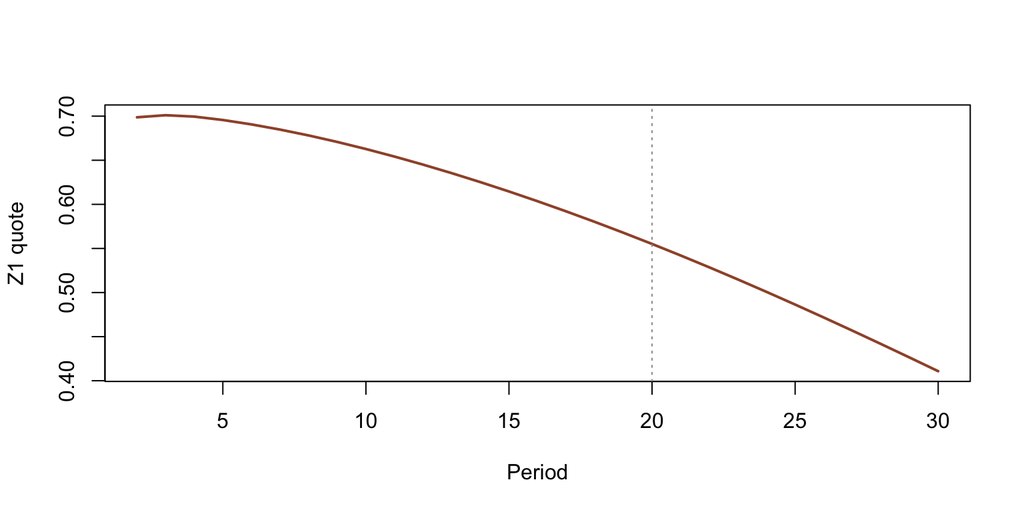

Isolated 6% foreign-bill-demand transition: successful period roots with an accelerating quote decline.

## Alternative closure and stopping reason

All three OPENECO regime blocks are mapped together: four changed assigned unknowns across eight branch statements. The alternative makes both foreign household bill supplies demand conversions, both CBs residual bill purchasers, cash supply a CB balance-sheet level identity, and the quote a balance-of- payments flow ratio. It requires adapting Leeds’ nonzero CB net worth, gold and foreign-CB reserve holdings. Algebra fixtures show zero/near-zero denominators and negative quotes despite positive asset stocks. Assignment count does not establish full rank or attraction.

Its verdict is **awaiting `data_seps.xls`, EViews import/presample layout and original output fixtures**, with an explicitly different institutional experiment needed for Leeds. No OPENECO simulation was claimed. Detailed source lines and fixtures are in `qmd/reports/2026-10-03-openflex-alternative-closure.md` and `output/calibration/openflex_attack/alternative/`.

The checkpoint follows two requested focused work blocks. Hands-on time was not timed separately from unattended runtime, so no exhausted-hours claim is made. Measured new runtimes are 265.464 seconds for the full-state signed branches/control, 1.752 seconds for directional evaluation, and 265.114 seconds for the t30 depth screen. Stopping now gives the independent four-closure revision its bounded diagnostic verdict, rather than making stabilization its prerequisite. Additional candidate tests lack an isolated causal justification in the remaining channels and are explicitly deferred.

## What remains uncertain and what would change the verdict

- The full independent real-capital/net-worth matrix and constrained transition spectrum remain open; current evidence is a complete financial/consolidated cash audit plus admissible directional tests.
- The minimal delayed trade/price/wealth/valuation loop is not identified; channel interventions or new behavioural equations require separately named isolated experiments and full accounting checks.
- The supplied numerical benchmark retains rounded-presample accounting residuals. Native EViews and published-output agreement need author fixtures.
- OPENECO reproduction needs its actual workbook/imports and an explicitly adapted CB/reserve institution. Its text alone is insufficient.
- Reconsider integration only after an isolated configuration passes root, accounting, positive-domain/nonnegative-holding, t100 stationarity and signed/two-size attraction gates. No author/calibration/manuscript choice is inferred from this diagnostic.

The protection validator still verifies **200 files, including all 104 accepted caches**, both reference hashes and 21 launch hashes. Its verdict is unchanged protected bytes. The unrelated usage-script edit remains untouched. Source, failed runs, receipts and rendered decision remain uncommitted in this workspace; nothing was published or sent to collaborators.